# Auto MPG Data Analysis

### Load libraries

```r
library(knitr)
library(dplyr)
```

```r
library(corrplot)
library(visreg)
library(ggplot2)
#library(scatterplot3d)
```

## GitHub Documents

This is an R Markdown format used for publishing markdown documents to GitHub. When you click the **Knit** button all R code chunks are run and a markdown file (.md) suitable for publishing to GitHub is generated.

## Data Description

1. Title: Auto-Mpg Data
2. Sources:
1. Origin: This dataset was taken from the StatLib library which is maintained at Carnegie Mellon University. The dataset was used in the 1983 American Statistical Association Exposition.
2. Date: July 7, 1993
1. Past Usage:
   - See 2b (above)
   - Quinlan,R. (1993). Combining Instance-Based and Model-Based Learning. In Proceedings on the Tenth International Conference of Machine Learning, 236-243, University of Massachusetts, Amherst. Morgan Kaufmann.
2. Relevant Information:

This dataset is a slightly modified version of the dataset provided in the StatLib library. In line with the use by Ross Quinlan (1993) in predicting the attribute "mpg", 8 of the original instances were removed because they had unknown values for the "mpg" attribute. The original dataset is available in the file "auto-mpg.data-original".

"The data concerns city-cycle fuel consumption in miles per gallon, to be predicted in terms of 3 multivalued discrete and 5 continuous attributes." (Quinlan, 1993)

1. Number of Instances: 398
2. Number of Attributes: 9 including the class attribute
3. Attribute Information:
   1. mpg: continuous
   2. cylinders: multi-valued discrete
   3. displacement: continuous
   4. horsepower: continuous
   5. weight: continuous
   6. acceleration: continuous
   7. model year: multi-valued discrete
   8. origin: multi-valued discrete
   9. car name: string (unique for each instance)
4. Missing Attribute Values: horsepower has 6 missing values

## Including Code

You can include R code in the document as follows:

```r
data <- read.table("http://mlr.cs.umass.edu/ml/machine-learning-databases/auto-mpg/auto-mpg.data",header = T, col.names = c("mpg","cylinders","displacement","horsepower","weight","acceleration","model_year", "origin","car_name"))
```

### Descriptive Analysis

```r
str(data)
```

```
## 'data.frame':    397 obs. of  9 variables:
##  $ mpg         : num  15 18 16 17 15 14 14 14 15 15 ...
##  $ cylinders   : int  8 8 8 8 8 8 8 8 8 8 ...
##  $ displacement: num  350 318 304 302 429 454 440 455 390 383 ...
##  $ horsepower  : Factor w/ 94 levels "?","100.0","102.0",..: 35 29 29 24 42 47 46 48 40 37 ...
##  $ weight      : num  3693 3436 3433 3449 4341 ...
##  $ acceleration: num  11.5 11 12 10.5 10 9 8.5 10 8.5 10 ...
##  $ model_year  : int  70 70 70 70 70 70 70 70 70 70 ...
##  $ origin      : int  1 1 1 1 1 1 1 1 1 1 ...
##  $ car_name    : Factor w/ 305 levels "amc ambassador brougham",..: 37 232 15 162 142 55 224 242 2 102 ...
```

```r
#View(data)
```

```r
glimpse(data)
```

```
## Observations: 397
## Variables: 9
## $ mpg          <dbl> 15, 18, 16, 17, 15, 14, 14, 14, 15, 15, 14, 15, 1...
## $ cylinders    <int> 8, 8, 8, 8, 8, 8, 8, 8, 8, 8, 8, 8, 8, 4, 6, 6, 6...
## $ displacement <dbl> 350, 318, 304, 302, 429, 454, 440, 455, 390, 383,...
## $ horsepower   <fct> 165.0, 150.0, 150.0, 140.0, 198.0, 220.0, 215.0, ...
## $ weight       <dbl> 3693, 3436, 3433, 3449, 4341, 4354, 4312, 4425, 3...
## $ acceleration <dbl> 11.5, 11.0, 12.0, 10.5, 10.0, 9.0, 8.5, 10.0, 8.5...
## $ model_year   <int> 70, 70, 70, 70, 70, 70, 70, 70, 70, 70, 70, 70, 7...
## $ origin       <int> 1, 1, 1, 1, 1, 1, 1, 1, 1, 1, 1, 1, 1, 3, 1, 1, 1...
## $ car_name     <fct> buick skylark 320, plymouth satellite, amc rebel ...
```

```r
head(data)
```

```
##   mpg cylinders displacement horsepower weight acceleration model_year
## 1  15         8          350      165.0   3693         11.5         70
## 2  18         8          318      150.0   3436         11.0         70
## 3  16         8          304      150.0   3433         12.0         70
## 4  17         8          302      140.0   3449         10.5         70
## 5  15         8          429      198.0   4341         10.0         70
## 6  14         8          454      220.0   4354          9.0         70
##   origin           car_name
## 1      1  buick skylark 320
## 2      1 plymouth satellite
## 3      1      amc rebel sst
## 4      1        ford torino
## 5      1   ford galaxie 500
## 6      1   chevrolet impala
```

```r
summary(data)
```

```
##       mpg          cylinders      displacement     horsepower
##  Min.   : 9.00   Min.   :3.000   Min.   : 68.0   150.0  : 22
##  1st Qu.:17.50   1st Qu.:4.000   1st Qu.:104.0   90.00  : 20
##  Median :23.00   Median :4.000   Median :146.0   88.00  : 19
##  Mean   :23.53   Mean   :5.448   Mean   :193.1   110.0  : 18
##  3rd Qu.:29.00   3rd Qu.:8.000   3rd Qu.:262.0   100.0  : 17
##  Max.   :46.60   Max.   :8.000   Max.   :455.0   75.00  : 14
##                                                  (Other):287
##      weight      acceleration     model_year        origin
##  Min.   :1613   Min.   : 8.00   Min.   :70.00   Min.   :1.000
##  1st Qu.:2223   1st Qu.:13.90   1st Qu.:73.00   1st Qu.:1.000
##  Median :2800   Median :15.50   Median :76.00   Median :1.000
##  Mean   :2969   Mean   :15.58   Mean   :76.03   Mean   :1.574
##  3rd Qu.:3609   3rd Qu.:17.20   3rd Qu.:79.00   3rd Qu.:2.000
##  Max.   :5140   Max.   :24.80   Max.   :82.00   Max.   :3.000
##
##            car_name
##  ford pinto    :  6
##  amc matador   :  5
##  ford maverick :  5
##  toyota corolla:  5
##  amc gremlin   :  4
##  amc hornet    :  4
##  (Other)       :368
```

```r
#factor(data$model_year)['levels']
print("Unique model years")
```

```
## [1] "Unique model years"
```

```r
unique(data$model_year)
```

```
##  [1] 70 71 72 73 74 75 76 77 78 79 80 81 82
```

```r
print("Unique origin")
```

```
## [1] "Unique origin"
```

```r
unique(data$origin)
```

```
## [1] 1 3 2
```

```r
print("Unique cylinders")
```

```
## [1] "Unique cylinders"
```

```r
unique(data$cylinders)
```

```
## [1] 8 4 6 3 5
```

### Checking missing values

```r
anyNA(data)
```

```
## [1] FALSE
```

```r
is.na(data$horsepower)
```

[output not shown]

[output cut: 22 more lines]

## Data Cleaning

- Cylinders column should be factors (multi-valued discrete) not integer

```r
#factor(data,labels=c("I","II","III")) -- dplyr %>% method passing data$cylinder as argument to fator fn
data$cylinders = data$cylinders %>%
                 factor(labels = sort(unique(data$cylinders)))
```

- Horsepower is factor and it should be continuous numeric variable

```r
data$horsepower = as.numeric(levels(data$horsepower))[data$horsepower]
```

- Horsepower has some missing values. We will impute those by mean.

```r
#library(zoo)
#na.aggregate(DF)
#na_count <-sapply(x, function(y) sum(length(which(is.na(y)))))
#na_count <- data.frame(na_count)
#sum(is.na(data$horsepower))

colSums(is.na(data))
```

```
##          mpg    cylinders displacement   horsepower       weight
##            0            0            0            6            0
## acceleration   model_year       origin     car_name
##            0            0            0            0
```

```r
data$horsepower[is.na(data$horsepower)] = mean(data$horsepower,na.rm = T)
```

- Cylinders 3 & 5 has very low values. We can drop these cylinders

```r
#data %>% group_by(cylinders) %>% summarise(length(cylinders))

data %>% group_by(cylinders) %>% count(cylinders)
```

```
## # A tibble: 5 x 2
## # Groups:   cylinders [5]
##   cylinders     n
##   <fct>     <int>
## 1 3             4
## 2 4           204
## 3 5             3
## 4 6            84
## 5 8           102
```

```r
data <- data %>% filter(cylinders != 3 & cylinders != 5)
#p %>% group_by(cylinders) %>% summarise(length(cylinders))
```

- Converting Model Year to factor since it has few levels

```r
data$model_year = data$model_year %>%
                  factor(labels = sort(unique(data$model_year)))
```

- Converting Origin to factor since it has only 3 levels

```r
data$origin = data$origin %>%
                  factor(labels = sort(unique(data$origin)))
```

## Visual Analysis

[Learn ggplot](http://www.sthda.com/english/wiki/ggplot2-essentials)

- Accelration data is normaly distributed. Rest are right skewed.

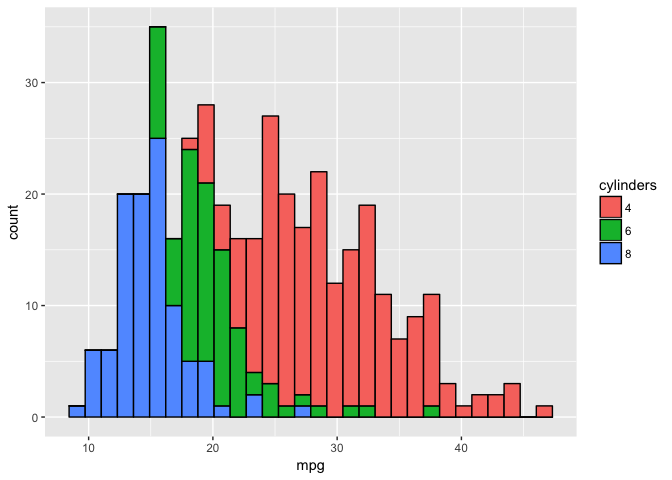

```r
library(reshape2)

ggplot(data,aes(mpg, fill=cylinders)) +
  geom_histogram(color="black")
```

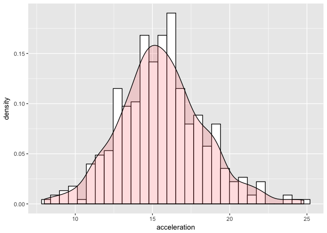

```r
ggplot(data, aes(x=acceleration)) +
 geom_histogram(aes(y=..density..), colour="black", fill="white")+
 geom_density(alpha=.2, fill="#FF6666")
```

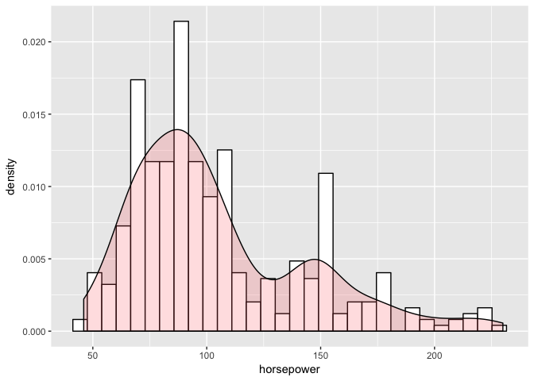

```r
ggplot(data, aes(x=horsepower)) +
 geom_histogram(aes(y=..density..), colour="black", fill="white")+
 geom_density(alpha=.2, fill="#FF6666")
```

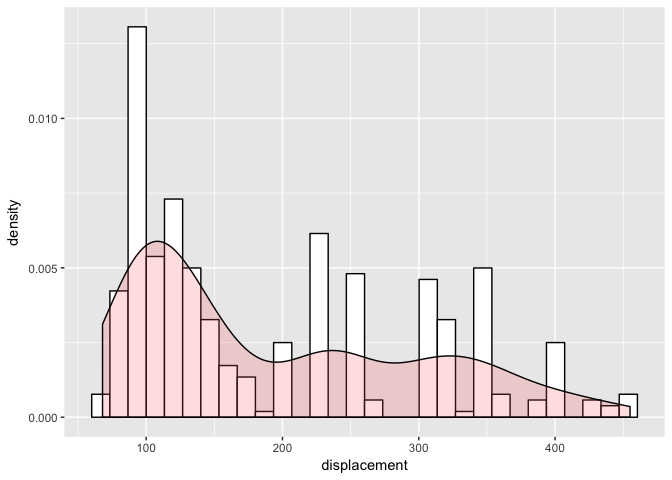

```r
ggplot(data, aes(x=displacement)) +
 geom_histogram(aes(y=..density..), colour="black", fill="white")+
 geom_density(alpha=.2, fill="#FF6666")
```

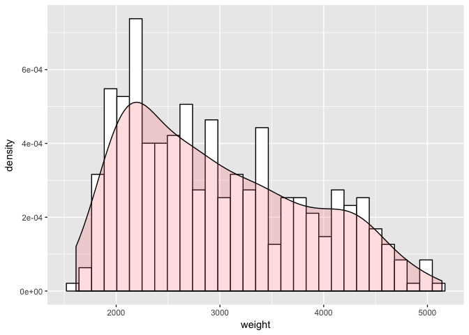

```r
ggplot(data, aes(x=weight)) +
 geom_histogram(aes(y=..density..), colour="black", fill="white")+
 geom_density(alpha=.2, fill="#FF6666")
```

```r
d <- melt(data[,-c(8:9)])
```

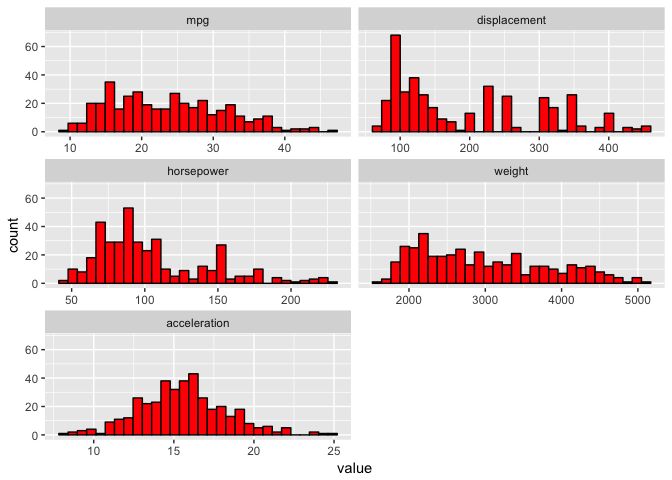

```r
ggplot(d,aes(value)) +
    facet_wrap(~variable,scales = "free_x",nrow = 3) +
    geom_histogram(colour="black", fill="red")
```

```r
#ggplot(data,aes(mpg, fill = model_year)) + geom_histogram(stat = "bin")
#hist(data$mpg)
```

### Checking for outliers

[What is a Boxplot?](http://www.clayford.net/statistics/a-note-on-boxplots-in-r/)

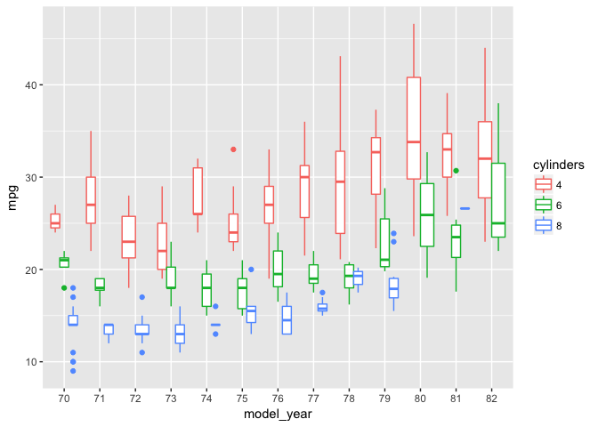

```r
ggplot(data, aes(model_year,mpg,color=cylinders)) +
  geom_boxplot()
```

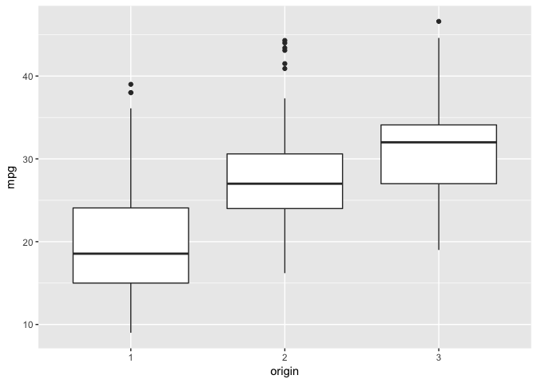

```r
ggplot(data, aes(origin,mpg)) +
  geom_boxplot()
```

- Origin 1 has heavy weighted cars (median ~ 3400)

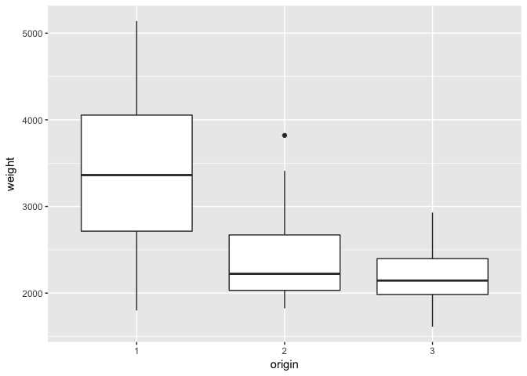

```r
ggplot(data, aes(origin,weight)) +
  geom_boxplot()
```

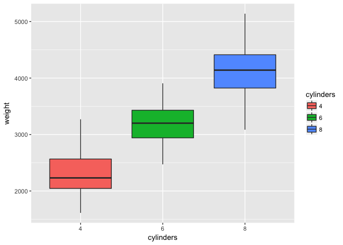

```r
ggplot(data, aes(cylinders,weight,fill=cylinders)) +
  geom_boxplot()
```

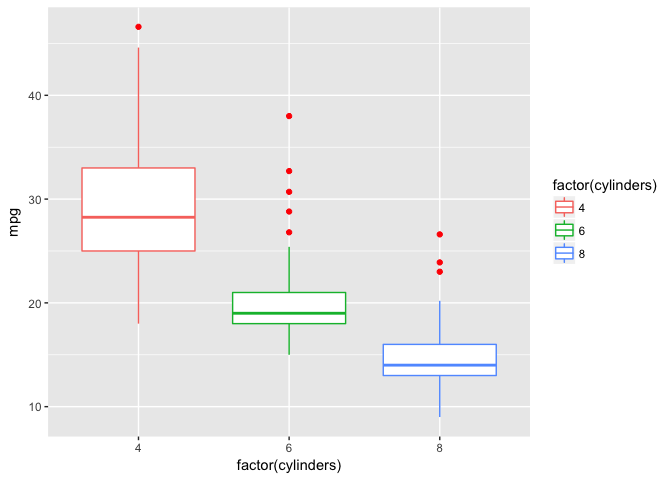

```r
ggplot(data, aes(x=factor(cylinders),y=mpg,color=factor(cylinders)))+
  geom_boxplot(outlier.color = "red")
```

```r
d <- melt(data[,-c(8:9)])
```

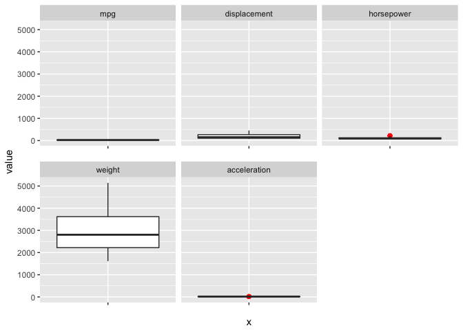

```r
ggplot(d,aes('',value)) +
    facet_wrap(~variable,scales = "free_x") +
    geom_boxplot(outlier.colour="red", outlier.shape=16, outlier.size=2, notch=F)
```

### Scatterplot

- Miles per gallon (mpg) decreasing with increase of the weight

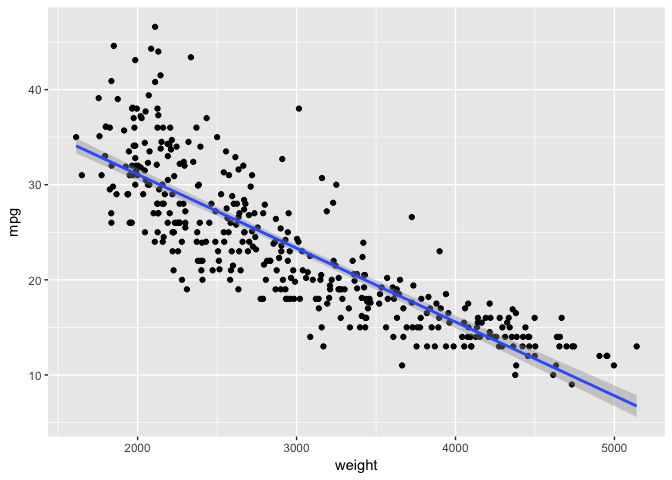

```r
ggplot(data,aes(weight,mpg)) +
  geom_point()+
  geom_smooth(method=lm)
```

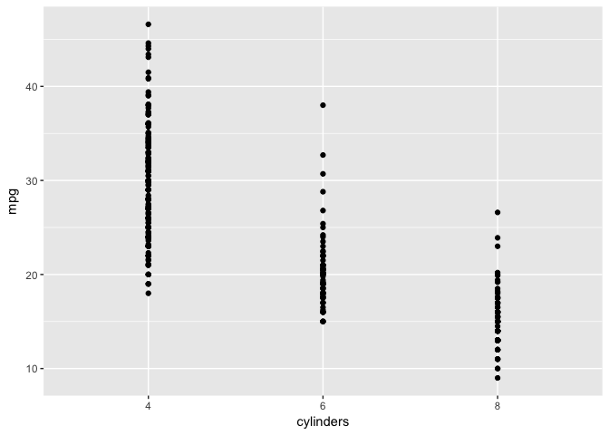

```r
ggplot(data,aes(cylinders,mpg)) +
  geom_point()+
  geom_smooth(method=lm)
```

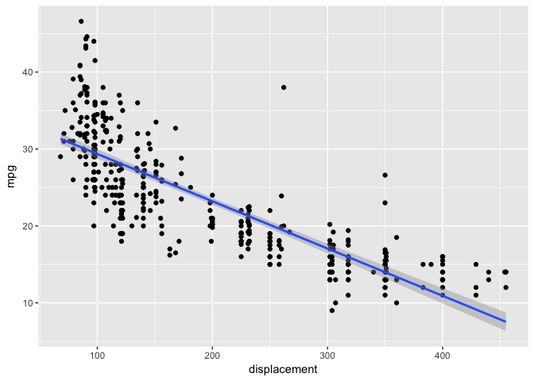

```r
ggplot(data,aes(displacement,mpg)) +
  geom_point()+
  geom_smooth(method=lm)
```

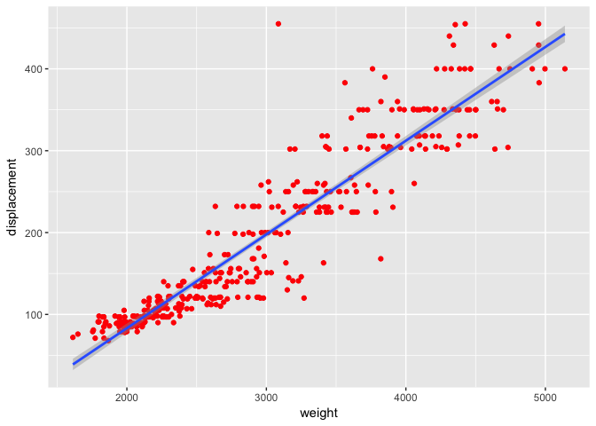

```r
ggplot(data,aes(weight, displacement)) +
  geom_point(color="red") +
  geom_smooth(method = lm)
```

- Weight, Horsepower and Displacement are highly correlated, so we can pick one attribute out of 3

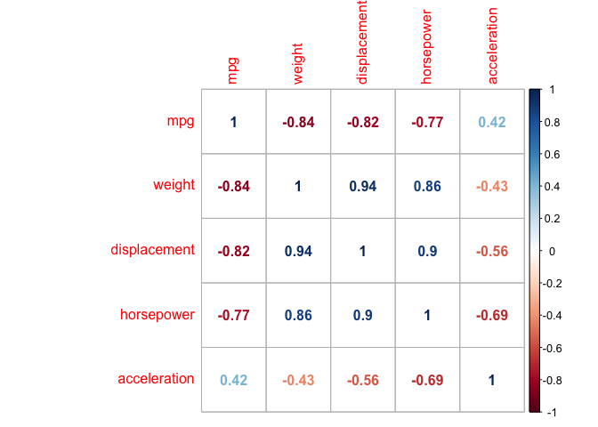

```r
newdata <- cor(data[ , c('mpg','weight', 'displacement', 'horsepower', 'acceleration')], use='complete')
corrplot(newdata, method = "number")
```

- 6 and 8 cylinders cars are majorly built in origin 1.

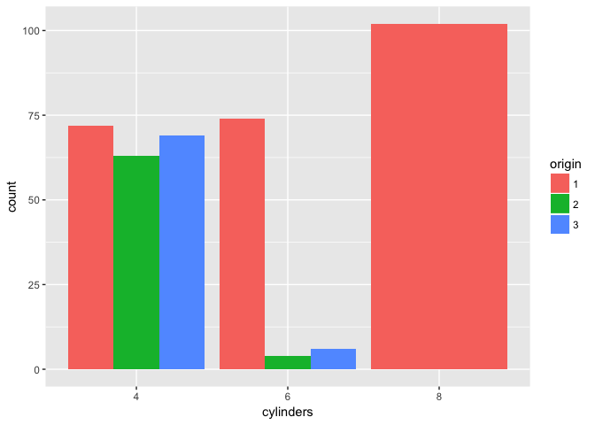

```r
ggplot(data, aes(cylinders,fill=origin)) +
  geom_bar(position = "dodge")
```

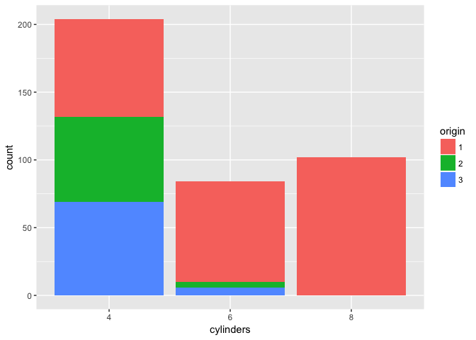

```r
ggplot(data, aes(cylinders,fill=origin)) +
  geom_bar(position = "stack")
```

- Significant drop in the car weights in origin 1. The reason behind it is increase in production of 4 cylinders cars those weighs less.

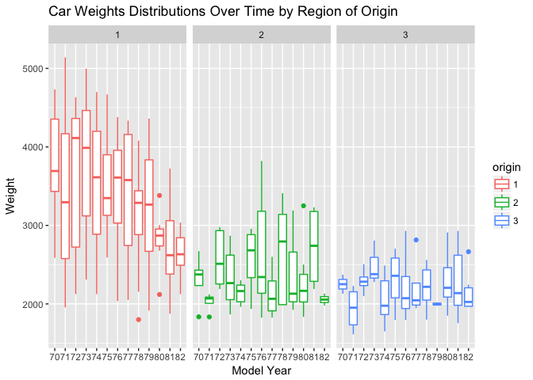

```r
ggplot(data, aes(model_year, y = weight, color=origin)) +
  geom_boxplot() +
  facet_wrap(~ origin) +
  xlab('Model Year') +
  ylab('Weight') +
  ggtitle('Car Weights Distributions Over Time by Region of Origin')
```

- We can see that over the year there was increase in the milege of the cars (Miles Per Gallon)

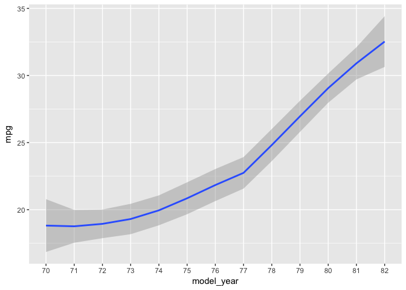

```r
 ggplot(data, aes(model_year,mpg,group=1))+geom_smooth()
```

- Significant drop in Car Engine's horsepower over the years

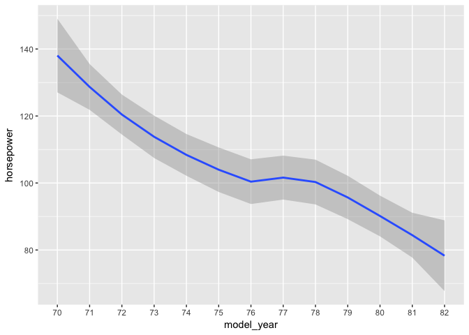

```r
 ggplot(data, aes(model_year,horsepower,group=1))+geom_smooth()
```